# Bike Lanes & Gentrification in Los Angeles

E.Sheild_N.Levine_G.Barrett-Jackson

12/8/21

# Introduction

Noting environmental, health, and other benefits, more and more municipalities are implementing complete streets plans that emphasize sustainable modes of transportation like biking. Advocates of these plans present them as a panacea for pollution, air quality, and congestion, among other ills. Challenging this rosy narrative, however, critics have posited a link between bicycle infrastructure and gentrification, citing anecdotal evidence of displacement in the wake of its installation.

This semester, we set out to test this empirically. With respect to the City of Los Angeles, we ask, what is the relationship between the installation of bicycle infrastructure and gentrification? On the basis of our lived experience in the region, we hypothesize that there is a positive relationship between the installation of bicycle infrastructure and gentrification.

# Background

In order to understand the socioeconomic implications of bicycle infrastructure, we first contextualize previous academic research supplemented with current news articles.

Focusing on Portland, OR and Chicago, IL, Flanagan et al. (2016) “identify a bias towards increased cycling infrastructure investment in areas of existing or increasing privilege.” Reviewing research methods used in this study was an important roadmap for us as the researchers pulled from census demographic data and ran linear regressions to estimate how changes in demographics associated with gentrification are related to cycling infrastructure investment.

Finally, we relied heavily on the teachings and research of our Professor, Carole Voulgaris. Her publication with other researches “Healthy for whom? Equity in the spatial distribution of cycling risks in Los Angeles, CA” provided good research methodological strategy and structure as well as inspired us to keep equity at the forefront of our research (Braun et. al., 2021).

Ahead of diving into our own data in the context of Los Angeles, these research bodies, and current news articles, helped us to think critically about our research question and hypothesis. We hope our research can supplement and contribute to the broader research body of social determinants of bicycle infrastructure and ridership.

# Data

We have conceptualized bicycle infrastructure in terms of means of transportation to work and bike lane length. We have conceptualized gentrification in terms of tenure, race, and median income.

The sample population for this study is the all census tracts in the City of Los Angeles. The analysis included the following categorical and continuous variables:

- Tenure: 2019 American Communities Survey, “Did this person live in this house or apartment 5 years ago?”
- Race (White): 2019 American Communities Survey, “What is Person 1’s race?”
- Median Income ($): 2019 American Communities Survey, “What was this person’s total income during the past 12 months?”
- Means of Transportation (Bike): 2019 American Communities Survey, “How did this person usually get to work last week?”
- Bikeways (Linear Feet): LACity GeoHub. This is our selected dependent variable that depends on and is influenced by all the other independent variables.

We pulled data from the American Communities Survey (ACS). To define bicycle infrastructure we settled on the amount of bike lane length (linear feet) per census tract. To accomplish this we retrieved a shapefile containing all the bike lanes in the City of LA through LA City GeoHub, uploaded that shapefile to ArcGIS Pro, clipped the bike lanes to a LA City census tract shapefile, used ArcGIS Pro’s “summarize within” function to calculate the bike lane length (linear feet) per census tract.

To narrow our scope and further define bike infrastructure, we only included Lane (69.98%), Protected Bike Lane (2.38%), Buffer Bike Lane (1.08%), and Path (0.75%), and excluded Sharrowed Route (14.48%), Route (11.04%), Bicycle Friendly Street (0.17%), Temp Removal Sharrowed Route (0.08%), and Detour Sharrowed Route (0.03%).

## Descriptive Statistics

The below descriptive statistics table provides an overview of our data.

[output not shown]

# Methods

After conducting our previous research and collecting our datasets, our research methods consisted of organizing, filtering, and compiling our data set and then ran a series linear regressions to analyze the linear of feet of bike lanes to the gentrification variables. Linear feet of bike lane per census tract was our dependent variable. Although interpreted in greater detail in the previous section, the purpose of this study is to assess whether bike lane length per census tracts is an indicator of areas of greater gentrification. Therefore, if our model has a significant positive coefficient for majority white, that means majority white census tracts have more bicycle lanes.

The first linear regression is a bi-variate analysis. A bi-variate relationship is between two variables, race (white) and bikeways (dependent). Put simply, a regression, which is all about prediction on an average, is a method for determining the relationship between quantifiable variables.

Secondly, we ran a series of multivariate regressions to control for the other independent variables. This regression model, lm function, predicts the effects of the change in gentrification on the linear feet of bike lanes.

Thirdly, based on our variables, we believe the non-linear transformation is a better fit for our data. We want to analyze if the % change in our variables is a better indicator than the actual value of a fixed increase/decrease. This statistical significance of pop_density to bike lane length inspired us to run log2, which with a base-two log our interpretation of the coefficient will have the effect of doubling the population density.

Lastly, based on the results of our log transformation we have decided to interact median income with majority white and majority non-white census tracts. An interaction is like a test to see the relationship between one of your dependent variables, bike lane length, and independent variable, median income. We are curious if the relationship between median income and bike lane length depends on the majority race in a tract. In the below section are the results and interpretations of each.

## Bivariate Analysis

### Median Income

In running a bivariate analysis between these two continuous variables, our 95% confidence interval does not include zero, and all values are positive. The correlation coefficient leads us to conclude, with 95% confidence, that there is a weak positive relationship between length of bike lanes and median income per census tract.

### Binary White

In our bivariate regression with binary_whitewhite (white majority census tracts) and sum_Length (feet of bike lane per census tract), we found, on average, that white majority census tracts in Los Angeles have 794.1 more feet of bike lane than non-white majority census tracts. This finding was significant at the 99% confidence level.

### Population Density

Since the confidence interval includes zero, we cannot say with 95% certainty that bikeway length is associated with population density, however we still find this to be helpful to our research in acknowledging that bike lane length amount neither has a strong negative or positive correlation (with 95% certainty) with population density.

## Multivariate Analysis

|  | Initial | Logged |
| --- | --- | --- |
| Constant | 4662.96 *** (p = 0.00) | 24642.75 *** (p = 0.00) |
| New residents (%) | 15206.92 (p = 0.06) | 14521.55 (p = 0.06) |
| Majority white (binary) | 153.62 (p = 0.63) | 14.67 (p = 0.96) |
| Log population density (people/sqmi) |  | -2169.78 *** (p = 0.00) |
| Median income ($) | -0.01 (p = 0.37) | -0.04 *** (p = 0.00) |
| Bike commuters (%) | 4912.19 (p = 0.78) | 26057.00 (p = 0.12) |
| N | 881 | 881 |
| R2 | 0.09 | 0.18 |
| *** p < 0.001; ** p < 0.01; * p < 0.05. |  |  |

## Interactions

|  | Logged | Interaction |
| --- | --- | --- |
| (Intercept) | 24642.75 *** (p = 0.00) | 22432.30 *** (p = 0.00) |
| percent_res_new | 14521.55 (p = 0.06) | 17053.54 * (p = 0.03) |
| binary_whitewhite | 14.67 (p = 0.96) | 1904.81 * (p = 0.01) |
| log_pop_density | -2169.78 *** (p = 0.00) | -2102.63 *** (p = 0.00) |
| med_income_E | -0.04 *** (p = 0.00) | 0.02 (p = 0.35) |
| percent_bike | 26057.00 (p = 0.12) | 28697.35 (p = 0.09) |
| binary_whitewhite:med_income_E |  | -0.07 ** (p = 0.01) |
| N | 881 | 881 |
| R2 | 0.18 | 0.18 |
| *** p < 0.001; ** p < 0.01; * p < 0.05. |  |  |

## Visualize Interaction

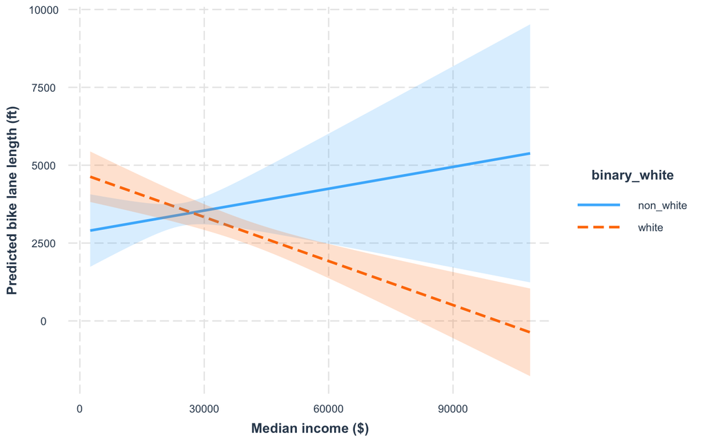

For non-white tracts, as median income increases, bike lane length also increases. Thus, there is a positive relationship For white census tracts, however, as median income increases, bike lane length decreases. Thus, there is a negative relationship. At approximately $30,000 the predicted bike lane length is the same regardless of non white and white majority census tracts.

# Discussion

Defining gentrification proved to be the most challenging aspect of this research project, and we identify as one salient weakness in this analysis. We defined gentrification by changes in neighborhood characteristics, whether that be economic, social, socioeconomic, etc. In order to define gentrification, we turned to various indicators provided in the ACS, tenure, median income, and race.

When conducting our analysis we found that the bivariate analysis demonstrates a weak positive relationship between bike lanes and median income. We found a white majority census have just under 800 more linear feet of bike lanes than non-white majority. For population density we can not say with 95% certainty that bike lane length is associated with population density. The multivariate analysis, when logged, improved our model fit nearly two-fold. Overall it is better to control for those variables, and analysis at the percent changes as opposed to unit increases. Finally, our interaction model highlights the nuances that exist in the increase of median income by racial makeup and bike lane length.

Time and the geographic context were limitations in our research project. Although we were able to accomplish a great deal of research throughout the seven week quantitative methodologies course, more time to find precedent studies and possibly run our analysis on multiple cities would have more thoroughly informed our research design and findings. As a group, we had little time for deep reflection of our findings. Some of our initial reflections brought to light questions about our findings. Specifically, does better bicycle infrastructure indicate areas of gentrification, or does gentrification as a phenomena spur better development of bicycle infrastructure?

Additional reflection centered around why bike lane length went down in white majority census tracts and income increased. We hypothesized that this dynamic stems from the data identifying that wealthy individuals can afford to have cars in the city and often live further out from the core of the city, meaning they are more inclined to drive. This is cited by Flanagan et. al. 2016. We were also surprised to find that as population density increased, bike lane length decreased. This finding led us to consider the autocentric nature of Los Angeles, even in its densest geographies many residents still own cars. The conflict of land uses (bike infrastructure vs. parking) is amplified in very dense regions, possibly accounting for why there is less bike infrastructure. This specific finding, that bike lane length decreases as population density increases, would be interesting to compare to other cities around the country.

# Conclusion

Supplementing the conclusions of Flanagan et al (2016), planners must engage diverse stakeholders in order to alleviate the continuation of inequitable distributions of cycling investment (Flanagan et. al. 2016).

Relating back to the published research by Ferenchak and Marshall (2021). We feel it would be interesting to explore how bicycle infrastructure can further the goals of Mobility Justice as defined by Karner et al., 2018. Karner et al. argues that Mobility justice is dependent upon three dimensions: “equitable access to participation in the planning process; equitable exposure to localized environmental burdens; and equitable distribution of the benefits of transportation investments and systems.” The historic renovation of how highways have impeded access and mobility of lower-income and minority populations, many of whom can not afford to drive, could be alleviated by a conscious effort of city planners to install alternative active modes of transportation, like bicycle lanes.

Previous research referenced in Ferenchak and Marshall’s work suggested that Black and Hispanic populations tend to be at higher risk on the road – particularly as pedestrians and bicyclists – than White populations. We feel an important supplement to where bicycle lanes are would be to assess how pedestrian safety differs between groups of varying privileges.

If we were to further this research, we would want to supplement our quantitative data with a qualitative method, such as interviews, that highlight the lived-experiences and ridership of individuals in these Census Block groups.

# References

- American Community Survey. 2019. 5 Year Estimates. https://data.census.gov/cedsci/
- Blame it on the bike: Does cycling contribute to a city’s gentrification? | Cities | The Guardian. (n.d.). Retrieved October 25, 2021, from https://www.theguardian.com/cities/2016/oct/05/blame-bike-cycling-contribute-city-gentrification
- Braun, Lindsay M., Huyen TK Le, Carole Turley Voulgaris, and Rachel C. Nethery. “Healthy for whom? Equity in the spatial distribution of cycling risks in Los Angeles, CA.” Journal of Transport & Health 23 (2021): 101227.
- Davis, J. (2021, July 15). The double-edged sword of upzoning. Brookings. https://www.brookings.edu/blog/how-we-rise/2021/07/15/the-double-edged-sword-of-upzoning/
- Ferenchak, N. N., & Marshall, W. E. (2021). Bicycling facility inequalities and the causality dilemma with socioeconomic/sociodemographic change. Transportation Research Part D: Transport and Environment, 97, 102920. https://doi.org/10.1016/j.trd.2021.102920
- Flanagan, E., Lachapelle, U., & El-Geneidy, A. (2016). Riding tandem: Does cycling infrastructure investment mirror gentrification and privilege in Portland, OR and Chicago, IL? Research in Transportation Economics, 60, 14–24. https://doi.org/10.1016/j.retrec.2016.07.027
- LADOT Walk & Bike Count. (n.d.). LADOT. Retrieved October 25, 2021, from https://ladot.lacity.org/walkbikecount
- Radio, S. C. P. (700, 00:44). Watch a decade of growth in LA’s bike infrastructure. Southern California Public Radio. https://archive.kpcc.org/news/2015/04/10/50849/watch-a-decade-of-growth-in-la-s-bike-infrastructu/
- What the Latest Census Data Says About L.A. City Bicycle Commuting. (2014, September 23). Streetsblog Los Angeles. https://la.streetsblog.org/2014/09/23/what-the-latest-census-data-says-about-l-a-city-bicycle-commuting/